# Exploration

Author

C. Grasland

```r
# Options générales
library(knitr)
options(max.print="80")
opts_chunk$set(echo=TRUE,
               cache=FALSE,
               prompt=FALSE,
               tidy=FALSE,
               comment=NA,
               message=FALSE,
               warning=FALSE,
               options(scipen=999))

# Selection de packages tidyverse
library(dplyr,quietly = T,warn.conflicts = F,verbose = F)
library(tidyr,quietly = T,warn.conflicts = F,verbose = F)
library(ggplot2,quietly = T,warn.conflicts = F,verbose = F)

# packages de cartographie
#library(sf,quietly = T, verbose=F)

# Packages d'enquête
#library(xtable)
#library(survey)
#library(questionr)
```

## Préparation des données

Le tableau du RPLS demande à être préparé soigneusement avant toute analyse statistique

### Sélection des variables

On décide de sélectionner un nombre limité d’indicateurs dont on veut mesurer la distribution globale pour l’ensemble de la zone d’étude.

```r
rpls<-readRDS("res/rpls.RDS")

sel<-rpls %>% select(nbp = NBPIECE,
                     sup = SURFHAB,
                     anc = CONSTRUCT,
                     ene = DPEENERGIE,
                     fin = FINAN)
```

### Recodage du type de financement

On procède à un recodage du type de financement en quatre catégories correspondant aux différents niveaux de logement social. On décide d’éliminer les cas complexes qui ne rentrent pas dans les quatre catégories

**N.B. Avant de transformer la variable en facteur, on a indiqué un order 1. 2. 3. 4. devant chaque type de financement afin que les graphiques qu nous réaliserons utilise un ordre logique.**

```r
sel$fin <- case_when(sel$fin == "10" ~ "1.PLAI",
                     sel$fin == "11" ~ "1.PLAI",
                     sel$fin == "12" ~ "2.PLUS",
                     sel$fin == "13" ~ "2.PLUS",
                     sel$fin == "14" ~ "3.PLS",
                     sel$fin == "15" ~ "3.PLS",
                     sel$fin == "16" ~ "4.PLI",
                     sel$fin == "17" ~ "4.PLI",
                     sel$fin == "50" ~ "2.PLUS",
                     sel$fin == "51" ~ "2.PLUS",
                     sel$fin == "52" ~ "2.PLUS",
                     sel$fin == "53" ~ "2.PLUS",
                     sel$fin == "54" ~ "2.PLUS",
                     sel$fin == "55" ~ "2.PLUS",
                     .default = NA
                     )
sel$fin<-as.factor(sel$fin)
```

### Recodage de la consommation d’énergie

```r
sel$ene<-as.factor(sel$ene)
```

### Résumé rapide

```r
summary(sel)
```

```
      nbp             sup              anc            ene            fin
 Min.   :1.000   Min.   : 10.00   Min.   :1830   D      :25019   1.PLAI: 4820
 1st Qu.:3.000   1st Qu.: 51.00   1st Qu.:1961   C      :24785   2.PLUS:59784
 Median :3.000   Median : 64.00   Median :1970   B      : 5658   3.PLS : 4931
 Mean   :3.197   Mean   : 63.77   Mean   :1974   A      : 2959   4.PLI :  154
 3rd Qu.:4.000   3rd Qu.: 76.00   3rd Qu.:1989   E      : 2914   NA's  : 3083
 Max.   :9.000   Max.   :230.00   Max.   :2019   (Other):  343
                                                 NA's   :11094
```

## Analyse univariée

On décide d’analyser plus précisément les caractéristiques des logements en fonction de leur type de financement. On définit une palette que l’on juge convenable pour représenter les différents types de logement.

### Type de financement

On réalise un tableau de dénombrement :

```r
sel %>% filter(is.na(fin)==FALSE) %>%
         count(fin) %>%
         mutate(pct=100*n/sum(n))
```

```
     fin     n        pct
1 1.PLAI  4820  6.9164431
2 2.PLUS 59784 85.7868530
3  3.PLS  4931  7.0757221
4  4.PLI   154  0.2209818
```

On utilise geom_bar pour créer un diagramme en bâtons. On ajoute une couleur avec un ordre indiquant l’ordre implicite des bénéficiaires du plus social au moins social

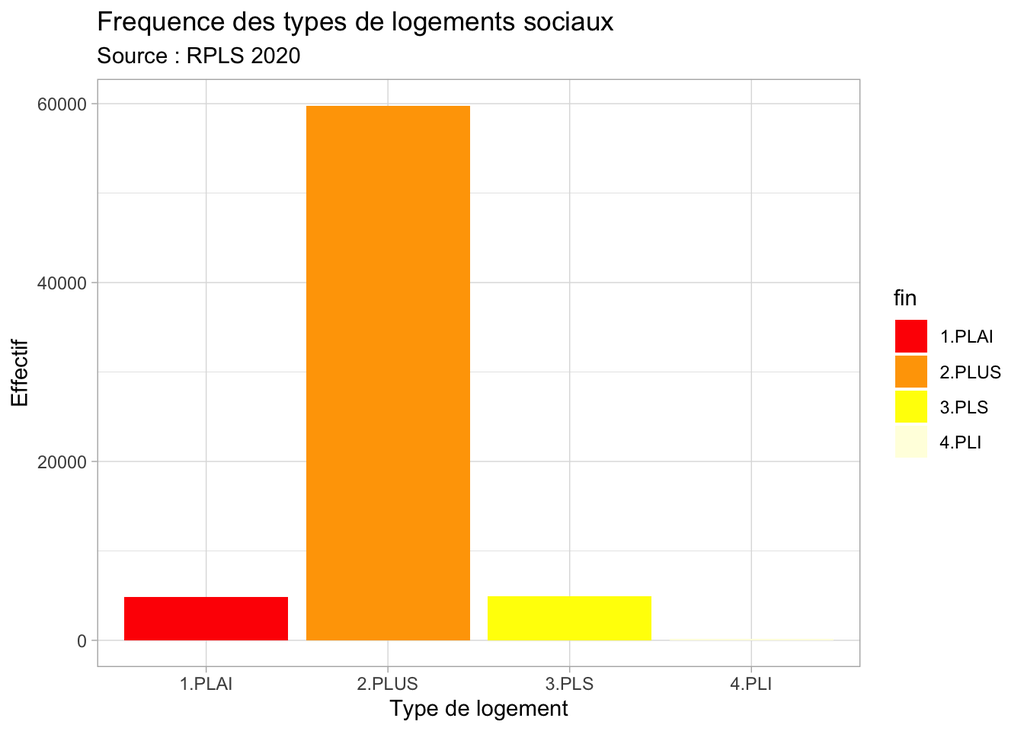

```r
mypal<-c("red","orange","yellow","lightyellow")

sel  %>% filter(is.na(fin)==FALSE) %>%
              ggplot()+
              aes(x=fin,fill=fin) +
              geom_bar(stat="count")+
              scale_fill_manual(values=mypal) +
              scale_x_discrete("Type de logement") +
              scale_y_continuous("Effectif") +
              ggtitle("Frequence des types de logements sociaux",
                      subtitle = "Source : RPLS 2020" ) +
              theme_light()
```

### Type énergétique

On reprend le programme précédent :

```r
sel %>% filter(is.na(ene)==FALSE) %>%
         count(ene) %>%
         mutate(pct=100*n/sum(n))
```

```
  ene     n         pct
1   A  2959  4.79749668
2   B  5658  9.17344920
3   C 24785 40.18450663
4   D 25019 40.56389636
5   E  2914  4.72453711
6   F   307  0.49774636
7   G    36  0.05836765
```

On réalise un diagramme en bâtons où l’on essaye de retrouver la palette de couleur des classes énergétiques

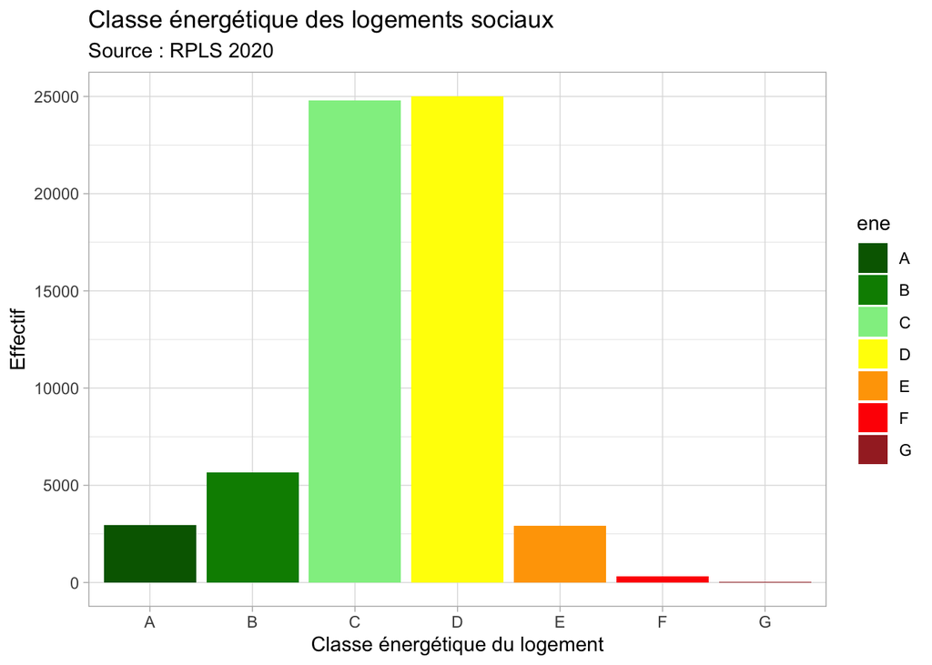

```r
mypal<-c("darkgreen","green4","lightgreen","yellow","orange","red1","brown")
sel %>% filter(is.na(ene)==F) %>%
              ggplot() +
              aes(x=ene, fill=ene) +
              geom_bar(stat="count",na.rm = T,) +
              scale_fill_manual(values=mypal) +
              scale_x_discrete("Classe énergétique du logement") +
              scale_y_continuous("Effectif") +
              ggtitle("Classe énergétique des logements sociaux",
                      subtitle = "Source : RPLS 2020" ) +
              theme_light()
```

### Nombre de pièces

Cette variable quantitative discrètre peut être analysée de deux façons différentes. On choisit isic de la traiter comme une variable qualitative :

```r
sel %>% filter(is.na(nbp)==FALSE) %>%
         count(nbp) %>%
         mutate(pct=100*n/sum(n))
```

```
  nbp     n          pct
1   1  4150  5.702742813
2   2 11935 16.400538669
3   3 28660 39.383279283
4   4 22130 30.410047821
5   5  5283  7.259660309
6   6   561  0.770900896
7   7    51  0.070081900
8   8     1  0.001374155
9   9     1  0.001374155
```

On transforme en variable catégorielle avant de réaliser le diagramme en bâtons

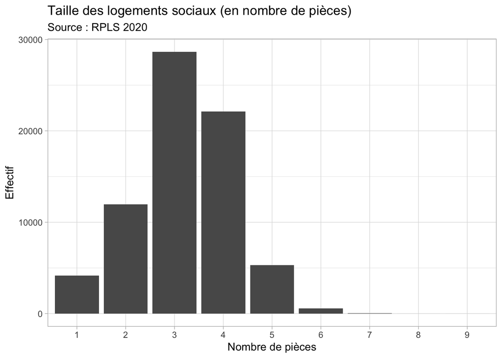

```r
sel %>% ggplot() + aes(x=as.factor(nbp)) +
              geom_bar(stat="count") +
              scale_x_discrete("Nombre de pièces") +
              scale_y_continuous("Effectif") +
              ggtitle("Taille des logements sociaux (en nombre de pièces)",
                      subtitle = "Source : RPLS 2020" ) +
              theme_light()
```

### Superficie habitable

Là il s’agit d’une véritable variable quantitative continue.

```r
summary(sel$sup)
```

```
   Min. 1st Qu.  Median    Mean 3rd Qu.    Max.
  10.00   51.00   64.00   63.77   76.00  230.00
```

On construit un histogramme puisque la variable est quantitative et continue. On utilise la fonction densité de probabilité pour mieux repérer les pics.

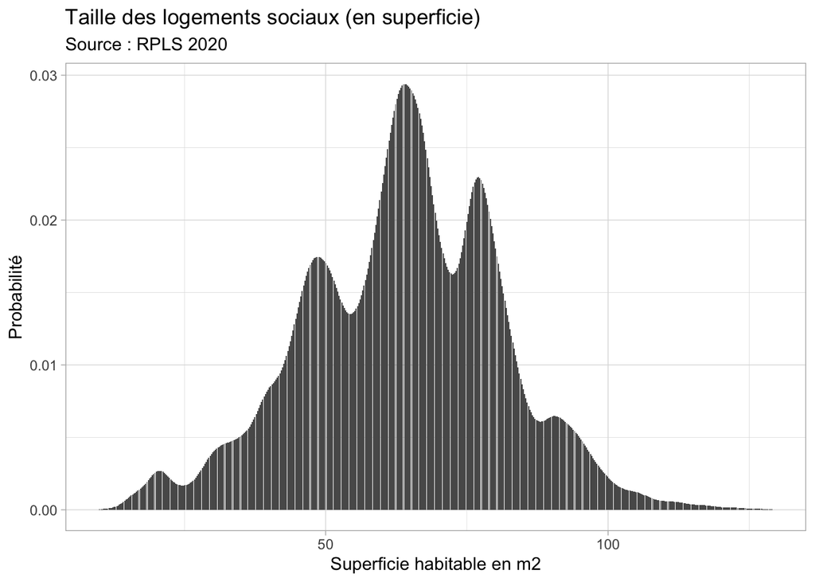

```r
ggplot(sel %>% filter(is.na(sup)==F, sup<130))+
             aes(x=sup) +
              geom_histogram(stat = "density") +
              scale_x_continuous("Superficie habitable en m2") +
              scale_y_continuous("Probabilité") +
                ggtitle("Taille des logements sociaux (en superficie)",
                      subtitle = "Source : RPLS 2020" ) +
              theme_light()
```

### Ancienneté

On construit un histogramme puisque la variable est quantitative et continue. On utilise la fonction densité de probabilité pour mieux repérer les pics.

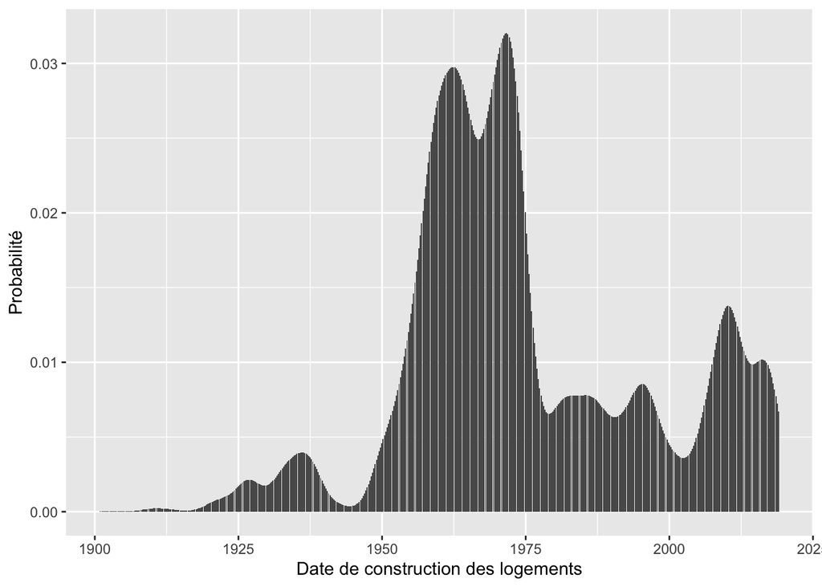

```r
ggplot(sel %>% filter(is.na(anc)==F, anc>1900))+
             aes(x=anc) +
              geom_histogram(stat="density")+
              scale_x_continuous("Date de construction des logements") +
              scale_y_continuous("Probabilité")
```

## Analyse bivariée

On donne juste quelques possibilités à titre d’exemple.

### X et Y qualitatives

Les deux variables sont de type qualitatif. On va donc créer un tableau de contingence, analyser les profils puis utiliser un test du chi-2.

```r
# Tableau de contingence
tab<-table(sel$fin,sel$ene)
kable(addmargins(tab), caption="Tableau de contingence")
```

Tableau de contingence

|  | A | B | C | D | E | F | G | Sum |
| --- | --- | --- | --- | --- | --- | --- | --- | --- |
| 1.PLAI | 530 | 477 | 1419 | 1355 | 297 | 32 | 13 | 4123 |
| 2.PLUS | 1723 | 4148 | 21877 | 21748 | 2147 | 259 | 15 | 51917 |
| 3.PLS | 700 | 554 | 898 | 682 | 107 | 3 | 5 | 2949 |
| 4.PLI | 0 | 35 | 53 | 4 | 54 | 8 | 0 | 154 |
| Sum | 2953 | 5214 | 24247 | 23789 | 2605 | 302 | 33 | 59143 |

```r
# Pourcentages en ligne
tab2<-100*prop.table(addmargins(tab,1),1)
kable(addmargins(tab2,2), digits=1, caption="Profil en ligne")
```

Profil en ligne

|  | A | B | C | D | E | F | G | Sum |
| --- | --- | --- | --- | --- | --- | --- | --- | --- |
| 1.PLAI | 12.9 | 11.6 | 34.4 | 32.9 | 7.2 | 0.8 | 0.3 | 100 |
| 2.PLUS | 3.3 | 8.0 | 42.1 | 41.9 | 4.1 | 0.5 | 0.0 | 100 |
| 3.PLS | 23.7 | 18.8 | 30.5 | 23.1 | 3.6 | 0.1 | 0.2 | 100 |
| 4.PLI | 0.0 | 22.7 | 34.4 | 2.6 | 35.1 | 5.2 | 0.0 | 100 |
| Sum | 5.0 | 8.8 | 41.0 | 40.2 | 4.4 | 0.5 | 0.1 | 100 |

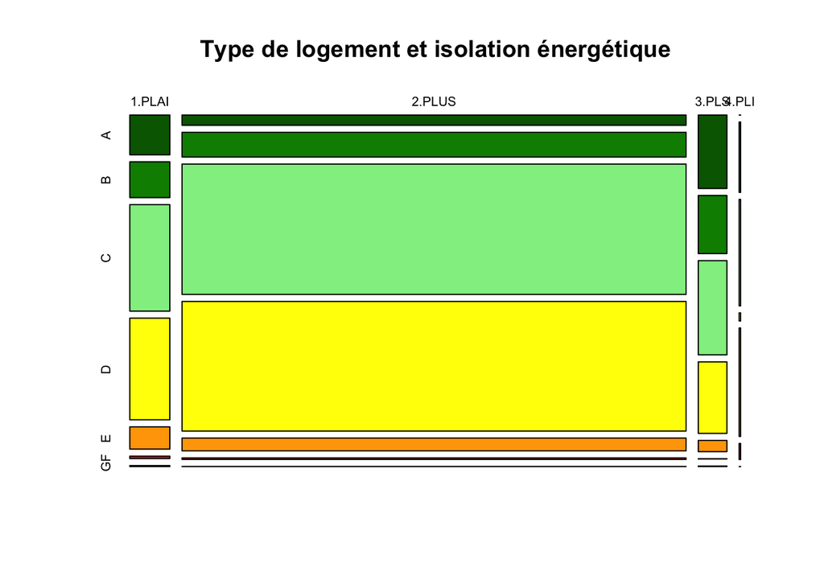

```r
# Graphique
mypal<-c("darkgreen","green4","lightgreen","yellow","orange","red1","brown")
plot(tab, col=mypal, main = "Type de logement et isolation énergétique")
```

```r
# Test du chi-2
test<-chisq.test(tab)
test
```

```
    Pearson's Chi-squared test

data:  tab
X-squared = 4387.8, df = 18, p-value < 0.00000000000000022
```

Le test du chi2 est incorrect car certaines catégories énergétiques sont trop peu représentées. On procède donc à des regroupements et on applique le même programme.

```r
# Fusion des classes
sel$ene4<-sel$ene
levels(sel$ene4)<-c("AB","AB","C","D","EFG","EFG","EFG")

# Tableau de contingence
tab<-table(sel$fin,sel$ene4)
kable(addmargins(tab), caption="Tableau de contingence")
```

Tableau de contingence

|  | AB | C | D | EFG | Sum |
| --- | --- | --- | --- | --- | --- |
| 1.PLAI | 1007 | 1419 | 1355 | 342 | 4123 |
| 2.PLUS | 5871 | 21877 | 21748 | 2421 | 51917 |
| 3.PLS | 1254 | 898 | 682 | 115 | 2949 |
| 4.PLI | 35 | 53 | 4 | 62 | 154 |
| Sum | 8167 | 24247 | 23789 | 2940 | 59143 |

```r
# Pourcentages en ligne
tab2<-100*prop.table(addmargins(tab,1),1)
kable(addmargins(tab2,2), digits=1, caption="Profil en ligne")
```

Profil en ligne

|  | AB | C | D | EFG | Sum |
| --- | --- | --- | --- | --- | --- |
| 1.PLAI | 24.4 | 34.4 | 32.9 | 8.3 | 100 |
| 2.PLUS | 11.3 | 42.1 | 41.9 | 4.7 | 100 |
| 3.PLS | 42.5 | 30.5 | 23.1 | 3.9 | 100 |
| 4.PLI | 22.7 | 34.4 | 2.6 | 40.3 | 100 |
| Sum | 13.8 | 41.0 | 40.2 | 5.0 | 100 |

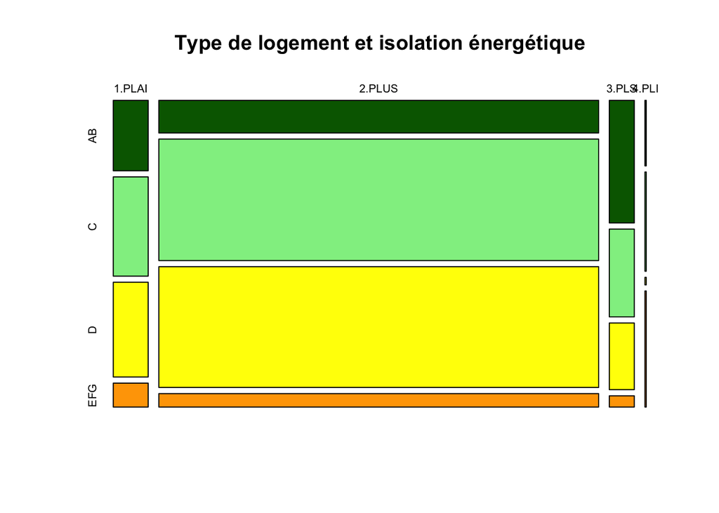

```r
# Graphique

mypal<-c("darkgreen","lightgreen","yellow","orange")
plot(tab, col=mypal, main = "Type de logement et isolation énergétique")
```

```r
# Test du chi-2
test<-chisq.test(tab)
test
```

```
    Pearson's Chi-squared test

data:  tab
X-squared = 3336.8, df = 9, p-value < 0.00000000000000022
```

### Y quantitative et X qualitative

On va prendre comme exemple la relation entre la surface des logements et leur type de financement. On commence par calculer les paramètres principaux, puis on fait un graphique et enfin on teste l’existence d’une relation.

```r
# Paramètres principaux
tapply(sel$sup, sel$fin,summary, simplify=T)
```

```
$`1.PLAI`
   Min. 1st Qu.  Median    Mean 3rd Qu.    Max.
     14      49      65      64      77     190

$`2.PLUS`
   Min. 1st Qu.  Median    Mean 3rd Qu.    Max.
   10.0    53.0    65.0    64.6    76.0   230.0

$`3.PLS`
   Min. 1st Qu.  Median    Mean 3rd Qu.    Max.
  15.00   44.00   63.00   58.37   72.00  128.00

$`4.PLI`
   Min. 1st Qu.  Median    Mean 3rd Qu.    Max.
   37.0    56.0    70.0    67.9    80.0   101.0
```

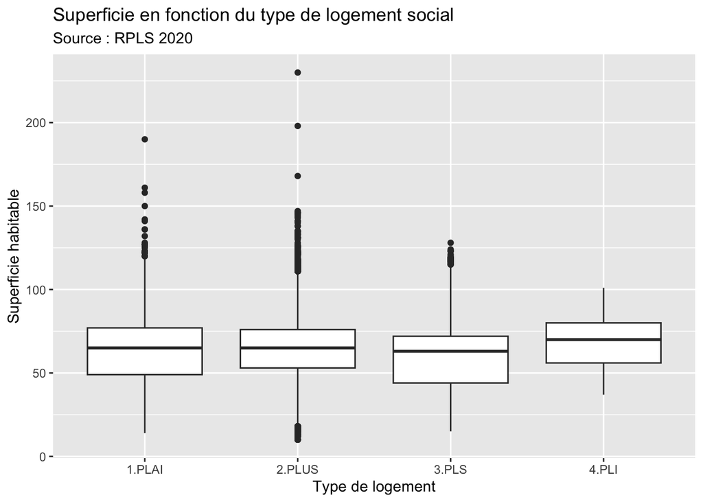

```r
# Boxplot
sel %>% filter(is.na(fin) == F) %>%
                   ggplot() + aes(y=sup, x=fin) +
                   geom_boxplot() +
                   scale_x_discrete("Type de logement") +
                   scale_y_continuous("Superficie habitable") +
                   ggtitle("Superficie en fonction du type de logement social",
                           subtitle = "Source : RPLS 2020" )
```

```r
# Analyse de variance
mod <- lm(sel$sup~sel$fin)
summary(mod)
```

```
Call:
lm(formula = sel$sup ~ sel$fin)

Residuals:
    Min      1Q  Median      3Q     Max
-54.604 -11.604   0.396  11.635 165.396

Coefficients:
              Estimate Std. Error t value             Pr(>|t|)
(Intercept)    64.0029     0.2492 256.834 < 0.0000000000000002 ***
sel$fin2.PLUS   0.6010     0.2591   2.320              0.02034 *
sel$fin3.PLS   -5.6375     0.3504 -16.087 < 0.0000000000000002 ***
sel$fin4.PLI    3.8932     1.4162   2.749              0.00598 **
---
Signif. codes:  0 '***' 0.001 '**' 0.01 '*' 0.05 '.' 0.1 ' ' 1

Residual standard error: 17.3 on 69685 degrees of freedom
  (3083 observations deleted due to missingness)
Multiple R-squared:  0.008535,  Adjusted R-squared:  0.008492
F-statistic: 199.9 on 3 and 69685 DF,  p-value: < 0.00000000000000022
```

On effectue un test :

```r
mod<-lm(sel$sup~sel$fin)
summary(mod)
```

```
Call:
lm(formula = sel$sup ~ sel$fin)

Residuals:
    Min      1Q  Median      3Q     Max
-54.604 -11.604   0.396  11.635 165.396

Coefficients:
              Estimate Std. Error t value             Pr(>|t|)
(Intercept)    64.0029     0.2492 256.834 < 0.0000000000000002 ***
sel$fin2.PLUS   0.6010     0.2591   2.320              0.02034 *
sel$fin3.PLS   -5.6375     0.3504 -16.087 < 0.0000000000000002 ***
sel$fin4.PLI    3.8932     1.4162   2.749              0.00598 **
---
Signif. codes:  0 '***' 0.001 '**' 0.01 '*' 0.05 '.' 0.1 ' ' 1

Residual standard error: 17.3 on 69685 degrees of freedom
  (3083 observations deleted due to missingness)
Multiple R-squared:  0.008535,  Adjusted R-squared:  0.008492
F-statistic: 199.9 on 3 and 69685 DF,  p-value: < 0.00000000000000022
```

### Superficie et ancienneté

On calcule le coefficient de corrélation et l’équation de la droite de régression décrivant la relation entre superficie et date de construction.

```r
cor.test(sel$anc, sel$sup)
```

```
    Pearson's product-moment correlation

data:  sel$anc and sel$sup
t = 34.374, df = 72770, p-value < 0.00000000000000022
alternative hypothesis: true correlation is not equal to 0
95 percent confidence interval:
 0.1192475 0.1335464
sample estimates:
      cor
0.1264035
```

```r
mod2<-lm(sel$sup~sel$anc)
summary(mod2)
```

```
Call:
lm(formula = sel$sup ~ sel$anc)

Residuals:
   Min     1Q Median     3Q    Max
-53.58 -11.45   0.19  12.36 168.56

Coefficients:
               Estimate  Std. Error t value            Pr(>|t|)
(Intercept) -125.672212    5.511582  -22.80 <0.0000000000000002 ***
sel$anc        0.095953    0.002791   34.37 <0.0000000000000002 ***
---
Signif. codes:  0 '***' 0.001 '**' 0.01 '*' 0.05 '.' 0.1 ' ' 1

Residual standard error: 17.4 on 72770 degrees of freedom
Multiple R-squared:  0.01598,   Adjusted R-squared:  0.01596
F-statistic:  1182 on 1 and 72770 DF,  p-value: < 0.00000000000000022
```

On réalise un graphique avec ggplot qui reproduit l’ajustement linéaire utilisé et on y ajoute un ajustement non linéaire afin de pouvoir visualiser la tendance générale et les cycles autour de celle-ci.

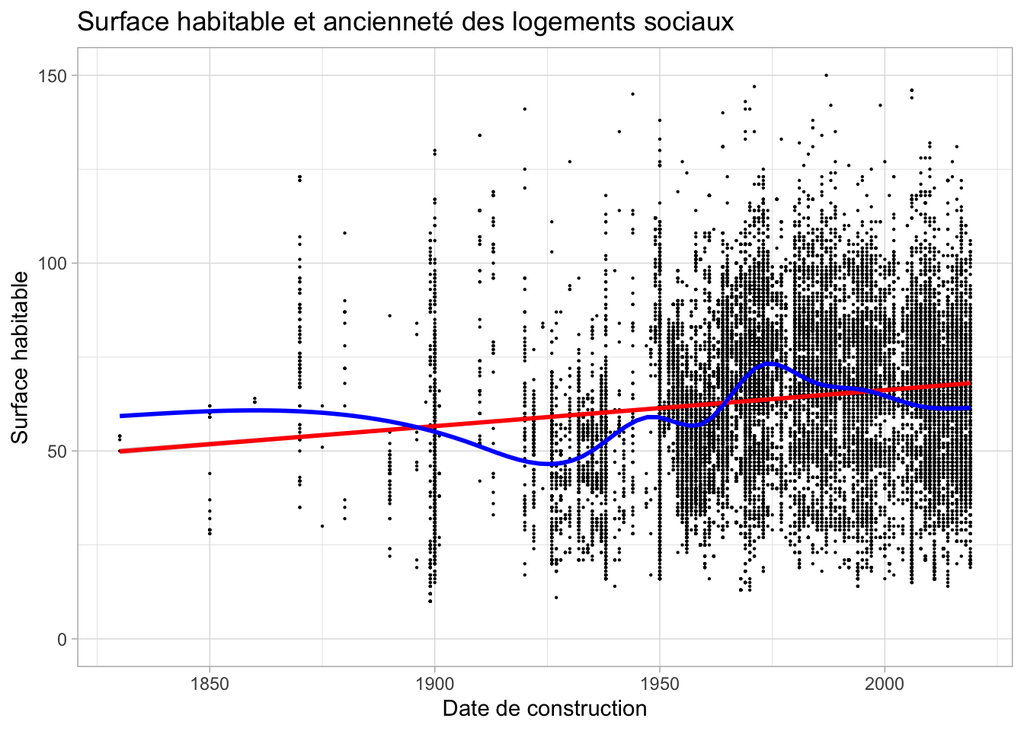

```r
sel %>% ggplot() +aes(x=anc, y = sup) +
                  geom_point(size=0.1) +
                  geom_smooth(method="lm",col="red") +
                  geom_smooth(col="blue", se=F)+
                  scale_x_continuous("Date de construction") +
                  scale_y_continuous("Surface habitable",limits = c(0,150)) +
                  ggtitle("Surface habitable et ancienneté des logements sociaux") +
                  theme_light()
```